# Kaggle: Titanic EDA

# Sex and Companion

```r
sex_sur <- table(all$Sex, all$Survived)
sex_sur
```

```
##
##          Died Survived
##   female   81      233
##   male    468      109
```

```r
summary(sex_sur) #significant association
```

```
## Number of cases in table: 891
## Number of factors: 2
## Test for independence of all factors:
##  Chisq = 263.05, df = 1, p-value = 3.712e-59
```

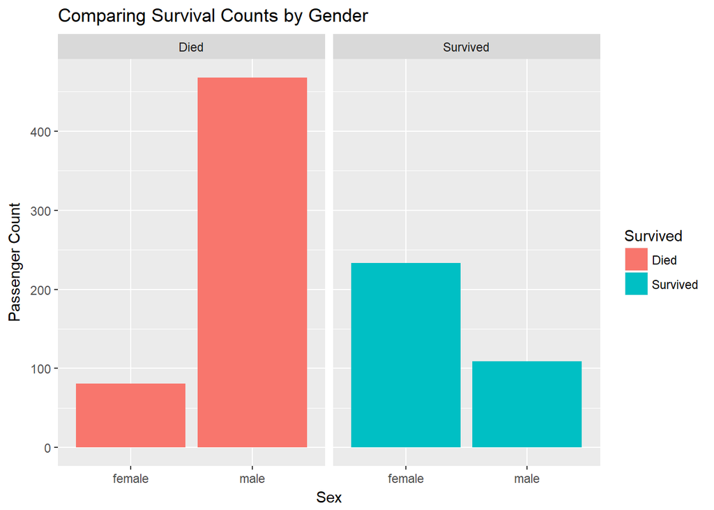

```r
ggplot(all[all$isTrain == 1,], aes(x = Sex, fill = Survived)) +
  geom_bar(stat ="count", position = "identity") +
  facet_grid(~Survived) +
  ggtitle("Comparing Survival Counts by Gender") +
  ylab("Passenger Count") +
  guides(fill=guide_legend(title="Survived"))
```

Many more males died than females.

# Parch and Sibsp

```r
parch_sur <- table("Number of Parents/Children"= all$Parch, all$Survived)
parch_sur
```

```
##
## Number of Parents/Children Died Survived
##                          0  445      233
##                          1   53       65
##                          2   40       40
##                          3    2        3
##                          4    4        0
##                          5    4        1
##                          6    1        0
##                          9    0        0
```

```r
summary(parch_sur) #too significant
```

```
## Number of cases in table: 891
## Number of factors: 2
## Test for independence of all factors:
##  Chisq = NaN, df = 7, p-value = NA
##  Chi-squared approximation may be incorrect
```

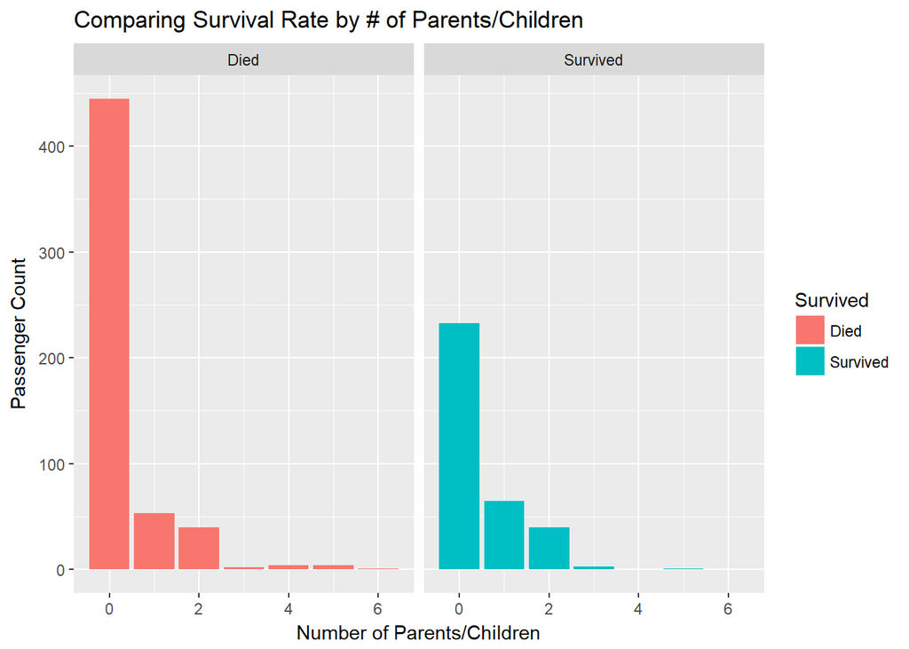

```r
ggplot(all[all$isTrain == 1,], aes(x = Parch, fill = Survived)) +
  geom_bar(stat ="count", position = "identity") +
  facet_grid(~Survived) +
  xlab("Number of Parents/Children") +
  ylab("Passenger Count") +
  ggtitle("Comparing Survival Rate by # of Parents/Children")+
  guides(fill=guide_legend(title="Survived"))
```

Very similar distribution…seems not informative.

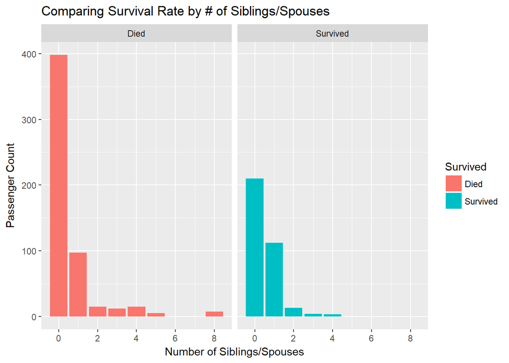

```r
ggplot(all[all$isTrain == 1,], aes(x = SibSp, fill = Survived)) +
  geom_bar(stat ="count", position = "identity") +
  facet_grid(~Survived) +
  xlab("Number of Siblings/Spouses") + ylab("Passenger Count") +
  ggtitle("Comparing Survival Rate by # of Siblings/Spouses")+
  guides(fill=guide_legend(title="Survived"))
```

Again, very similar distribution. Combine both variables to make ‘Companions’ feature

# Make hasCompanions Feature

1 if passenger traveled with a companion 0 if passenger traveled alone

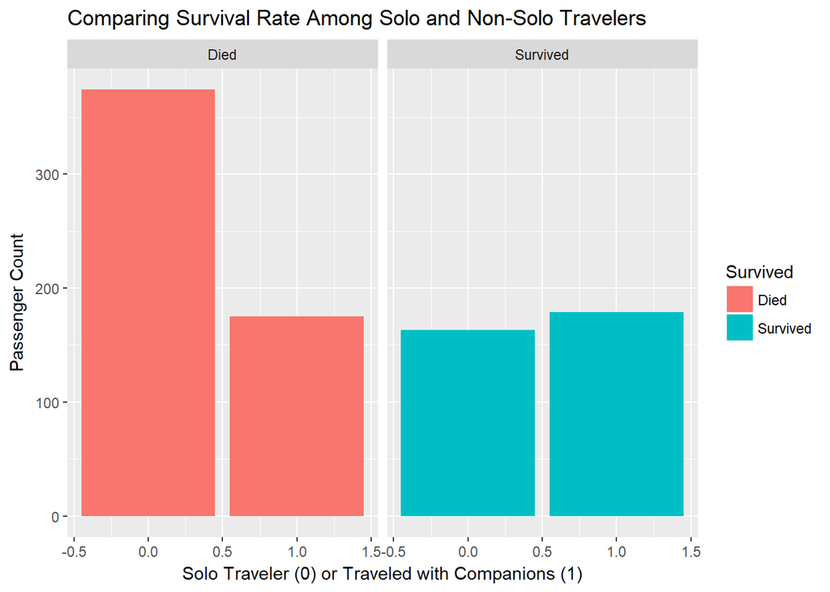

```r
all$Companions <- all$Parch + all$SibSp
#make dummy variable
all$hasCompanion <- as.numeric(all$Companions > 0)

ggplot(all[all$isTrain == 1,], aes(x = hasCompanion, fill = Survived)) +
  geom_bar(stat ="count", position = "identity") +
  facet_grid(~Survived) +
  xlab("Solo Traveler (0) or Traveled with Companions (1)") +  ylab("Passenger Count") +
  ggtitle("Comparing Survival Rate Among Solo and Non-Solo Travelers")+
  guides(fill=guide_legend(title="Survived"))
```

No distinction between solo traveler or those who traveled with companions among those survived. Take a closer look if this variable is correlated with other variables.

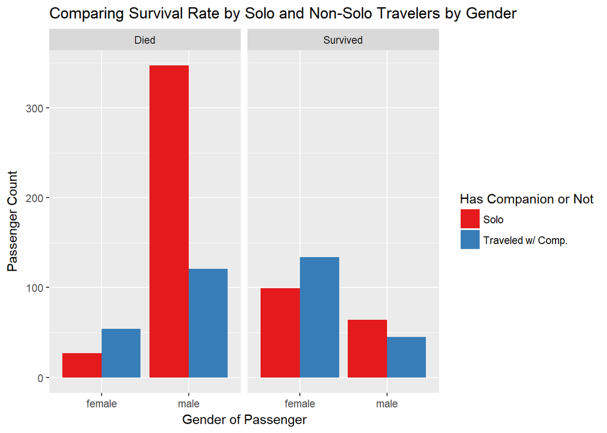

```r
####See if having a companion is interacting with gender. interaction terms.
#table(all$Sex, hasCompanion = all$hasCompanion, "Survived" = all$Survived)

ggplot(all[all$isTrain == 1,], aes(x = factor(Sex), fill = factor(hasCompanion, labels = c("Solo", "Traveled w/ Comp.")))) +
  geom_bar(stat ="count", position = "dodge") +
  scale_fill_brewer(palette = "Set1") +
  facet_grid(~Survived) +
  xlab("Gender of Passenger") +  ylab("Passenger Count") +
  ggtitle("Comparing Survival Rate by Solo and Non-Solo Travelers by Gender")+
  guides(fill=guide_legend(title="Has Companion or Not"))
```

```r
#investigate number companions closely to see if we can see more patterns
table(all$Companions, all$Survived)
```

```
##
##      Died Survived
##   0   374      163
##   1    72       89
##   2    43       59
##   3     8       21
##   4    12        3
##   5    19        3
##   6     8        4
##   7     6        0
##   10    7        0
```

Seems that those with four or more members are more likely to die.

# Create isSmallFamily Variable

```r
#make new variable isSmallFamily

all$isSmallFamily <- 0
all$isSmallFamily[all$Companions >= 4] <- 1

prop.table(table(isSmallFamily = all$isSmallFamily, Survived = all$Survived),1)
```

```
##              Survived
## isSmallFamily      Died  Survived
##             0 0.5995175 0.4004825
##             1 0.8387097 0.1612903
```

# Embarked

```r
unique(all$Embarked)
```

```
## [1] S C Q
## Levels: C Q S
```

```r
embarked_sur <- table(all$Embarked, all$Survived)
embarked_sur
```

```
##
##     Died Survived
##   C   75       93
##   Q   47       30
##   S  427      219
```

```r
summary(embarked_sur) #pretty significant.
```

```
## Number of cases in table: 891
## Number of factors: 2
## Test for independence of all factors:
##  Chisq = 25.964, df = 2, p-value = 2.301e-06
```

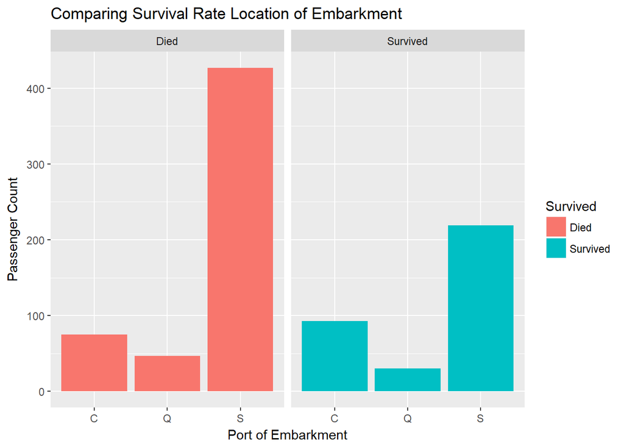

```r
ggplot(all[all$isTrain == 1,], aes(x = Embarked, fill = Survived)) +
  geom_bar(stat ="count", position = "identity") +
  facet_grid(~Survived) +
  xlab("Port of Embarkment") +  ylab("Passenger Count") +
  ggtitle("Comparing Survival Rate Location of Embarkment")+
  guides(fill=guide_legend(title="Survived"))
```

Again histograms are very similar.. probably some correlation with another variable

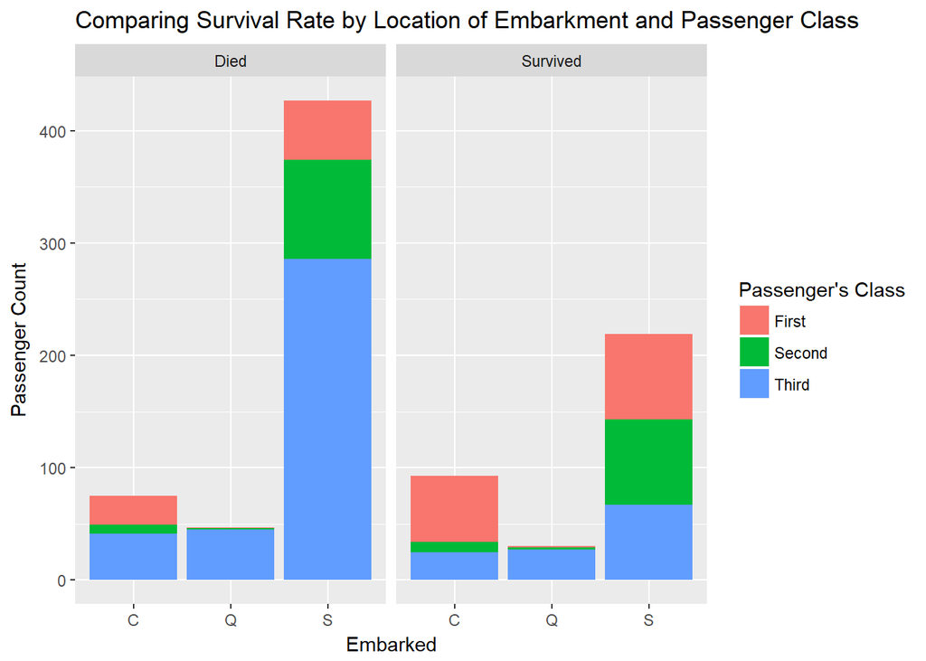

```r
#See interaction with Pclass
ggplot(all[all$isTrain == 1,], aes(x = Embarked, fill = factor(Pclass, labels = c("First", "Second", "Third")))) +
  geom_bar(stat ="count", position = "stack") +
  facet_grid(~Survived) +
  ylab("Passenger Count") +
  ggtitle("Comparing Survival Rate by Location of Embarkment and Passenger Class")+
  guides(fill=guide_legend(title="Passenger's Class"))
```

Not much associations.

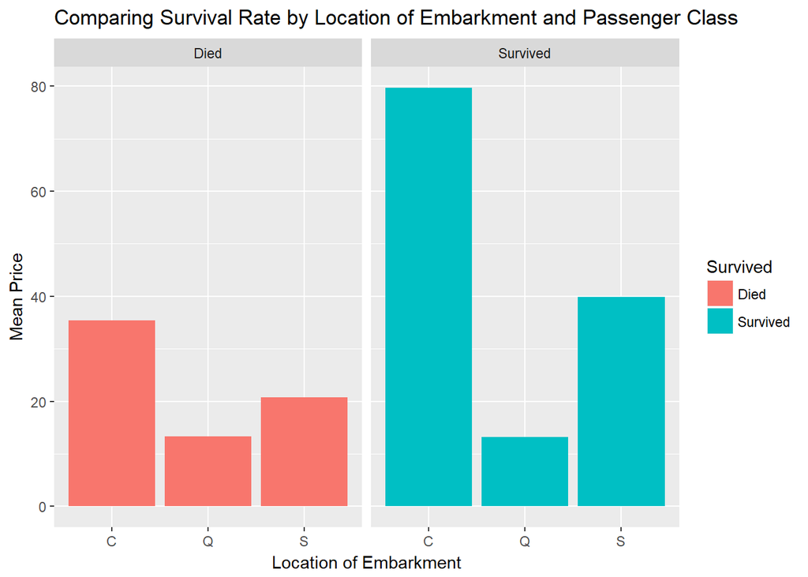

```r
#ANy trends with ticket prices?
#check the mean ticket price per embarked
all %>%
  filter(!is.na(Survived)) %>%
  group_by(Embarked, Survived) %>%
  summarise(mean_price = mean(Fare)) %>%
  ggplot(aes(x = Embarked, y = mean_price, fill = factor(Survived, labels = c("Died", "Survived")))) +
    geom_bar(stat="identity" ) +
    xlab("Location of Embarkment") +
    ylab("Mean Price") +
    ggtitle("Comparing Survival Rate by Location of Embarkment and Passenger Class")+
    facet_grid(~Survived) +
    guides(fill=guide_legend(title="Survived"))
```

More expensive tickets embarked at Port C while cheapest itckets were at Port Q. Let’s keep embarked varibable for now.

# Embarked and Fare_cat

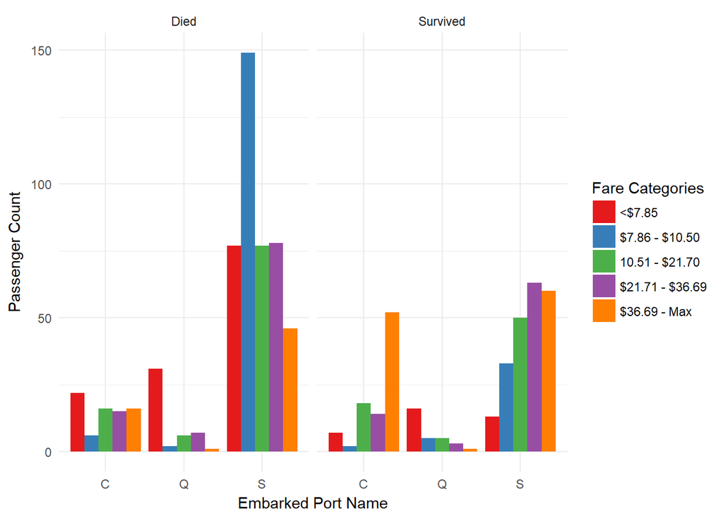

```r
#cuts

ggplot(all[all$isTrain == 1,], aes(x = Embarked, fill = factor(Fare_cat, labels = fare_cat_labels))) +
  geom_bar(stat = "count", position = "dodge") +
  scale_fill_brewer(palette = "Set1") +
  facet_grid(~Survived) +
  theme_minimal() +
  xlab("Embarked Port Name") +
  ylab("Passenger Count") +
  guides(fill=guide_legend(title="Fare Categories"))
```

```r
#Make percentages by port
port_fare_df <- all %>%
  filter(isTrain == 1, !is.na(Embarked)) %>%
  group_by(Embarked, Fare_cat, Survived) %>%
  summarise(n = n()) %>%
  ungroup() %>%
  group_by(Embarked) %>%
  mutate(embarked_sum = sum(n),
    embarked_percentage = round(n/embarked_sum,2))
port_fare_df
```

```
## # A tibble: 30 x 6
## # Groups:   Embarked [3]
##    Embarked Fare_cat Survived     n embarked_sum embarked_percentage
##      <fctr>   <fctr>   <fctr> <int>        <int>               <dbl>
##  1        C        1     Died    22          168                0.13
##  2        C        1 Survived     7          168                0.04
##  3        C        2     Died     6          168                0.04
##  4        C        2 Survived     2          168                0.01
##  5        C        3     Died    16          168                0.10
##  6        C        3 Survived    18          168                0.11
##  7        C        4     Died    15          168                0.09
##  8        C        4 Survived    14          168                0.08
##  9        C        5     Died    16          168                0.10
## 10        C        5 Survived    52          168                0.31
## # ... with 20 more rows
```

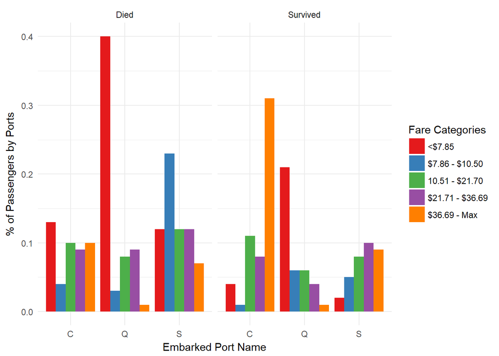

```r
ggplot(port_fare_df, aes(x = Embarked,y = embarked_percentage, fill = factor(Fare_cat, labels = fare_cat_labels))) +
  geom_bar(stat = "identity", position = "dodge") +
  scale_fill_brewer(palette = "Set1") +
  facet_grid(~Survived) +
  theme_minimal() +
  xlab("Embarked Port Name") +
  ylab("% of Passengers by Ports") +
  guides(fill=guide_legend(title="Fare Categories"))
```

Almost the same..only emphasizes certain bars. Except now, cheapest who embarked at port Q were more likely to die.

# Interaction terms with Embarked and Fare_cat

```r
#Make fifteen total interaction terms for 3 embarked * 5 farecat
emb_fare_int <- as.data.frame(matrix(rep(0,nrow(all)*15), nrow = nrow(all), ncol = 15))

col_names <- character()
for (port in c("C", "Q", "S")){
  for(cat in 1:5){
   col_names <-  c(col_names, paste("Embarked",port,":","Fare_cat",cat,sep = ""))
  }
}
#change col names
colnames(emb_fare_int) <- col_names

i = 1
for (port in c("C", "Q", "S")){
  for(cat in 1:5){
    emb_fare_int[i] <- as.numeric(all$Embarked == port & all$Fare_cat == cat)
    i <- i + 1
  }
}


check <- cbind(all[,c("Embarked", "Fare_cat")], emb_fare_int)
str(check) #ALL GOOD!
```

```
## 'data.frame':    1309 obs. of  17 variables:
##  $ Embarked           : Factor w/ 3 levels "C","Q","S": 3 1 3 3 3 2 3 3 3 1 ...
##  $ Fare_cat           : Factor w/ 5 levels "1","2","3","4",..: 1 5 2 5 2 2 5 3 3 4 ...
##  $ EmbarkedC:Fare_cat1: num  0 0 0 0 0 0 0 0 0 0 ...
##  $ EmbarkedC:Fare_cat2: num  0 0 0 0 0 0 0 0 0 0 ...
##  $ EmbarkedC:Fare_cat3: num  0 0 0 0 0 0 0 0 0 0 ...
##  $ EmbarkedC:Fare_cat4: num  0 0 0 0 0 0 0 0 0 1 ...
##  $ EmbarkedC:Fare_cat5: num  0 1 0 0 0 0 0 0 0 0 ...
##  $ EmbarkedQ:Fare_cat1: num  0 0 0 0 0 0 0 0 0 0 ...
##  $ EmbarkedQ:Fare_cat2: num  0 0 0 0 0 1 0 0 0 0 ...
##  $ EmbarkedQ:Fare_cat3: num  0 0 0 0 0 0 0 0 0 0 ...
##  $ EmbarkedQ:Fare_cat4: num  0 0 0 0 0 0 0 0 0 0 ...
##  $ EmbarkedQ:Fare_cat5: num  0 0 0 0 0 0 0 0 0 0 ...
##  $ EmbarkedS:Fare_cat1: num  1 0 0 0 0 0 0 0 0 0 ...
##  $ EmbarkedS:Fare_cat2: num  0 0 1 0 1 0 0 0 0 0 ...
##  $ EmbarkedS:Fare_cat3: num  0 0 0 0 0 0 0 1 1 0 ...
##  $ EmbarkedS:Fare_cat4: num  0 0 0 0 0 0 0 0 0 0 ...
##  $ EmbarkedS:Fare_cat5: num  0 0 0 1 0 0 1 0 0 0 ...
```

Concatenate interaction terms to whole dataset

```r
all <- cbind(all, emb_fare_int)
```

# Age

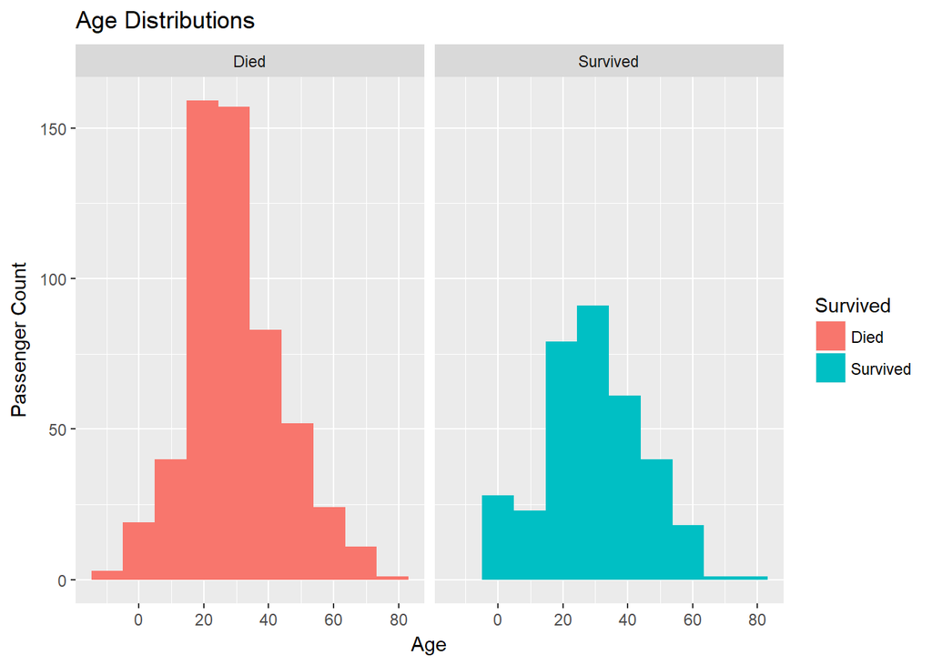

```r
ggplot(all[all$isTrain == 1,], aes(x = Age, fill = Survived))+
  geom_histogram(bins = 10) +
  ylab("Passenger Count") +
  ggtitle("Age Distributions")+
  facet_grid(~Survived)
```

There are negative ages! Interesting

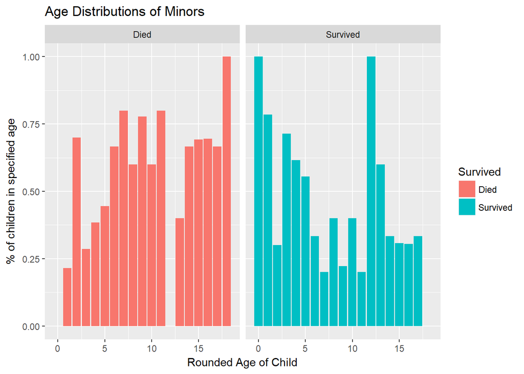

```r
#Change negative ages to average of age
all$Age[all$Age < 0] <- median(all$Age)


#investigate distribution of young folks who survived
#(notice the small spike on the left hand side)
all %>%
  filter(isTrain == 1 & Age < 18) %>%
  mutate(rounded_age = round(Age)) %>%
  group_by(rounded_age, Survived) %>%
  summarise(n = n()) %>% #still grouped by Age
  mutate(age_group_tot = sum(n),
         age_sur_per = n/age_group_tot) %>%

  ggplot(aes(x = rounded_age,y= age_sur_per, fill = Survived)) +
    geom_bar(stat = "identity") +
    facet_grid(~Survived) +
    xlab("Rounded Age of Child") +
    ylab("% of children in specified age") +
    ggtitle("Age Distributions of Minors")
```

Seems to be bimodal distribution. However, decided to not include the following code because this leads to overfitting. These only account for a small percentage of the data.

```r
# #make dummy variable for young kids (< 6 years old)
#   #do not make dummy variable for older teens. may be just samplingn issues.
# all$isAdolescent <- 0
# all$isAdolescent[all$Age <= 6] <- 1
# table("Young child" = all$isAdolescent, all$Survived) #remember, there variety of passengers
# #adding this variable might add a good effect.
#
```

```r
#categorize age
#AGAIN, do NOT make cuts based on entire dataset.
cuts_age <- quantile(all[all$isTrain ==1, ]$Age, probs = seq(0,1,1/7), na.rm = T)
print("Bins for categorizing age")
```

```
## [1] "Bins for categorizing age"
```

```r
cuts_age
```

```
##        0% 14.28571% 28.57143% 42.85714% 57.14286% 71.42857% 85.71429%
##   0.42000  16.00000  21.00000  25.79873  30.39513  36.00000  45.00000
##      100%
##  80.00000
```

```r
#change lowest min of cuts_age to 0
cuts_age[1] <- 0

cuts_age
```

```
##        0% 14.28571% 28.57143% 42.85714% 57.14286% 71.42857% 85.71429%
##   0.00000  16.00000  21.00000  25.79873  30.39513  36.00000  45.00000
##      100%
##  80.00000
```

```r
age_cat_labels <- c("<16", "16-21", ">21-26", ">26-30", ">30-35", ">35-45", ">45-max(80)")
```

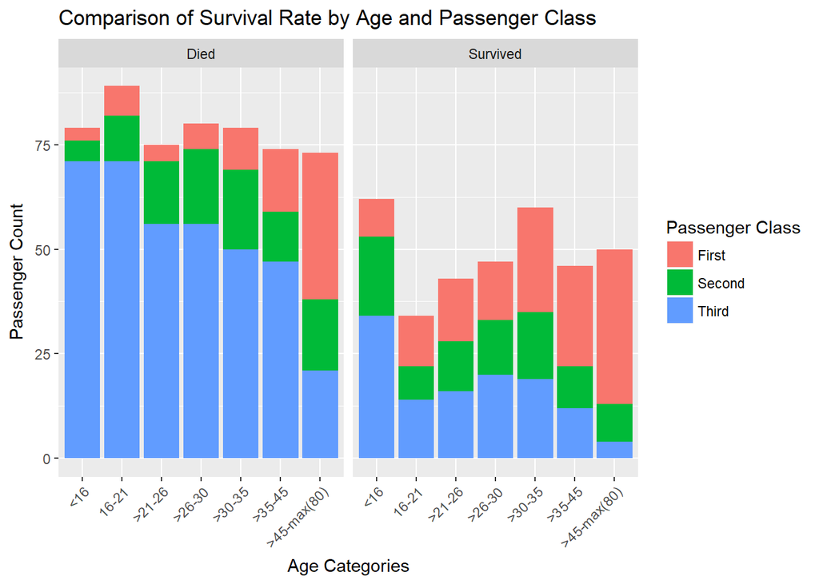

```r
#use numeric for data
all$age_cat <- factor(cut(all$Age, cuts_age, labels = seq(1,7,1),
                          include.lowest = T, right = T))
#summary(all$age_cat)
#use age labels for graphing
ggplot(all[all$isTrain == 1,], aes(x = factor(age_cat, labels = age_cat_labels), fill = factor(Pclass, labels = c("First", "Second", "Third")))) +
  geom_bar(stat ="count") +
  theme(axis.text.x = element_text(angle = 45, hjust =1)) +
  xlab("Age Categories") +
  ylab("Passenger Count") +
  ggtitle("Comparison of Survival Rate by Age and Passenger Class") +
  facet_grid(~Survived) +
  guides(fill=guide_legend(title="Passenger Class"))
```

There is again some patterns, but will not look further into this because this will lead to overfitting.

# Name

Investigate names.

```r
#Extract the mr. mrs. whatever.
tail(unique(all$Name))
```

```
## [1] "Henriksson, Miss. Jenny Lovisa" "Spector, Mr. Woolf"
## [3] "Oliva y Ocana, Dona. Fermina"   "Saether, Mr. Simon Sivertsen"
## [5] "Ware, Mr. Frederick"            "Peter, Master. Michael J"
```

```r
# #split ..very messy
# test <- strsplit("Ware, Mr. Frederick", ", ")
# test2 <- strsplit(test[[1]][2], ". ")
#
# #have to manually delete everything else..not intuitive
# first_names <- sub(pattern = ".*, ", "", x = "ware, Mr. Frederick")
# title <- sub(pattern= "\\. .*", "", x = first_names)
# title

all$name_title <- str_extract(all$Name, pattern = "([A-Za-z]+)\\.")
title <- all %>% group_by(name_title) %>% summarise(n = n()) %>% arrange(desc(n))
#title


title_surv <- table("Titles" = all$name_title, "Survived" = all$Survived)
title_surv
```

```
##            Survived
## Titles      Died Survived
##   Capt.        1        0
##   Col.         1        1
##   Countess.    0        1
##   Don.         1        0
##   Dona.        0        0
##   Dr.          4        3
##   Jonkheer.    1        0
##   Lady.        0        1
##   Major.       1        1
##   Master.     17       23
##   Miss.       55      127
##   Mlle.        0        2
##   Mme.         0        1
##   Mr.        436       81
##   Mrs.        26       99
##   Ms.          0        1
##   Rev.         6        0
##   Sir.         0        1
```

Note that all reverends died. Also the Captain did not survive. (Captain went down with the ship)! Also there are many titls..let’s group them!

```r
all$name_title_rev <- gsub(pattern = "Dr.|Col.|Major.|Mlle.|Countess.|Don.|Dona.|Jonkheer.|Lady.|Mme.|Sir.",
                           replacement = "Rare_Nobility", x = all$name_title)
all$name_title_rev <- gsub(pattern = "Ms.", replacement = "Miss.", x = all$name_title_rev)

print("Frequency table of name titles")
```

```
## [1] "Frequency table of name titles"
```

```r
table(all$name_title_rev)
```

```
##
##         Capt.       Master.         Miss.           Mr.          Mrs.
##             1            61           262           757           197
## Rare_Nobility          Rev.
##            23             8
```

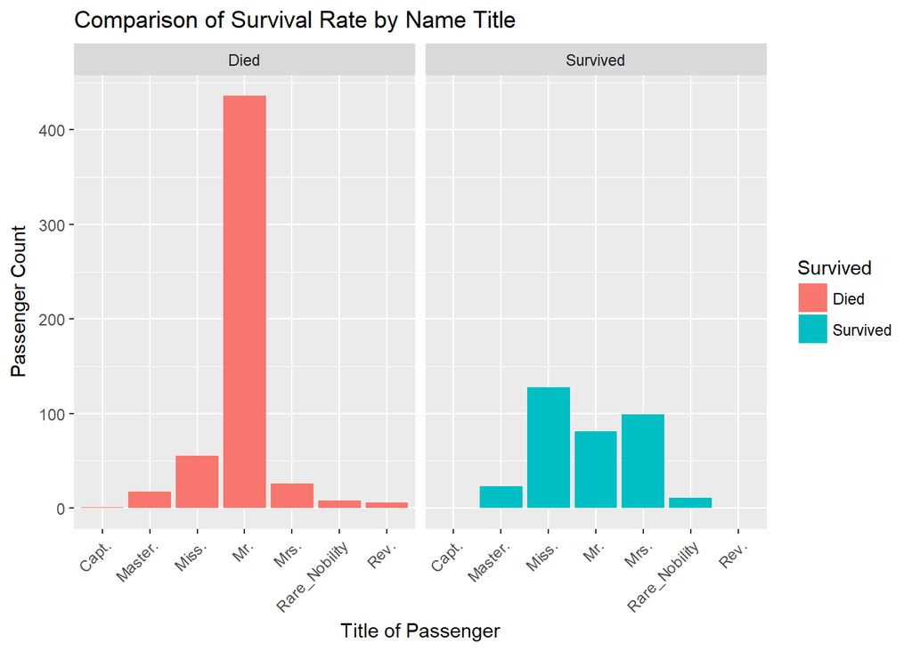

```r
#see correlation between title and survival.

ggplot(all[all$isTrain == 1,], aes(x = name_title_rev, fill = factor(Survived, labels = c("Died", "Survived")))) +
  geom_bar(stat ="count", position = "stack") +
  facet_grid(~Survived) +
  theme(axis.text.x = element_text(angle = 45, hjust =1)) +
  xlab("Title of Passenger") +  ylab("Passenger Count") +
  ggtitle("Comparison of Survival Rate by Name Title") +
  guides(fill=guide_legend(title="Survived"))
```

If you’re a Mr….You’ll probably not survive

```r
#Change to numeric so model cna read them

title_levels <- c("Mr.", "Miss.", "Mrs.", "Master.", "Rev.", "Capt.", "Rare_Nobility")
all$title_cat <- factor(all$name_title_rev, levels = title_levels, labels = 1:7)
table(all$title_cat)
```

```
##
##   1   2   3   4   5   6   7
## 757 262 197  61   8   1  23
```

# Name and Age

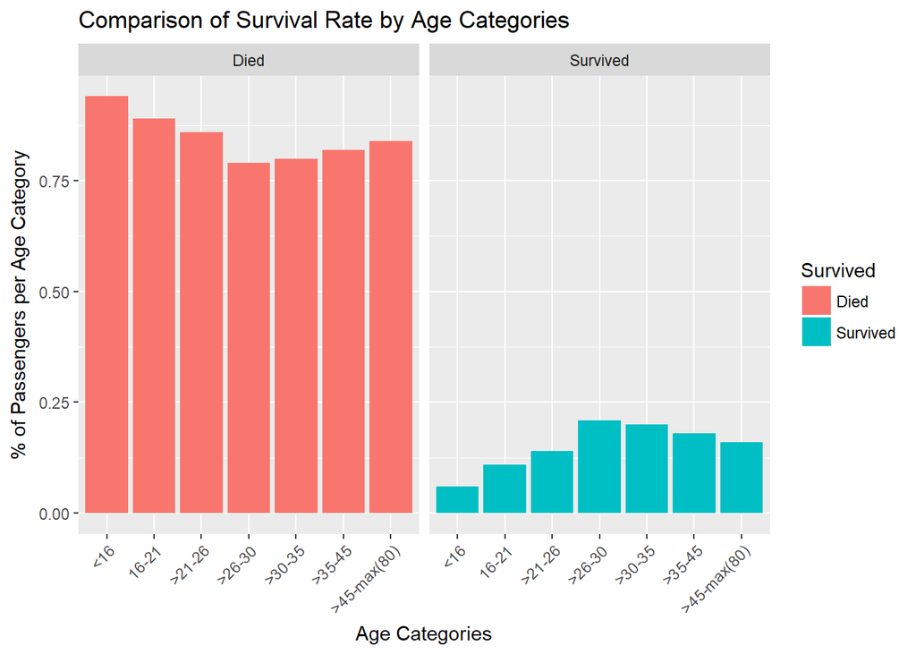

```r
#Mister and Age
all %>%
  filter(isTrain == TRUE & title_cat == 1) %>%
  group_by(title_cat, age_cat, Survived) %>%
  summarise(n = n()) %>%
  ungroup() %>%
  group_by(age_cat) %>%
  mutate(age_cat_sum = sum(n),
         age_cat_per = round(n/age_cat_sum,2)) %>%
  ggplot(aes(x = factor(age_cat, labels = age_cat_labels), y = age_cat_per, fill = Survived)) +
    geom_bar(stat = "identity", position = "identity") +
    xlab("Age Categories") +
    ylab("% of Passengers per Age Category") +
    ggtitle("Comparison of Survival Rate by Age Categories")  +
    guides(fill=guide_legend(title="Survived"))  +
    theme(axis.text.x = element_text(angle = 45, hjust =1)) +
    facet_grid(~Survived)
```

# Make Sex/Embarked variable numeric before modeling

```r
#instead of simple 1 0. let's trying using one hot encoding
#separtaes male and fmelae into sex_male, sex_female
all <- dummy.data.frame(all, names = c("Sex", "Embarked"), sep = "_")
```

# Check for Missing Data in Final Train

```r
#change target variable back to numeric
all$Survived <- ifelse(all$Survived == "Survived", 1,
                       ifelse(all$Survived == "Died", 0, NA))

final_train <- all %>% filter(isTrain == 1) %>%
  select(-c(Age, Name, name_title, name_title_rev, SibSp, Parch, Ticket, Fare, TicketNumber))
final_test <- all %>% filter(isTrain == 0) %>%
  select(-c(Survived, Age, Name, name_title, name_title_rev, SibSp, Parch, Ticket, Fare, TicketNumber))


missing_dat_final_tr <- colMeans(is.na(final_train))
#missing_dat_final_tr
paste("% of Missing data in training:", sum(missing_dat_final_tr), "%")
```

```
## [1] "% of Missing data in training: 0 %"
```

```r
missing_dat_final_te <- colMeans(is.na(final_test))
missing_dat_final_te
```

```
##         PassengerId              Pclass          Sex_female
##                   0                   0                   0
##            Sex_male          Embarked_C          Embarked_Q
##                   0                   0                   0
##          Embarked_S             isTrain           TicketLen
##                   0                   0                   0
##            Fare_cat          Companions        hasCompanion
##                   0                   0                   0
##       isSmallFamily EmbarkedC:Fare_cat1 EmbarkedC:Fare_cat2
##                   0                   0                   0
## EmbarkedC:Fare_cat3 EmbarkedC:Fare_cat4 EmbarkedC:Fare_cat5
##                   0                   0                   0
## EmbarkedQ:Fare_cat1 EmbarkedQ:Fare_cat2 EmbarkedQ:Fare_cat3
##                   0                   0                   0
## EmbarkedQ:Fare_cat4 EmbarkedQ:Fare_cat5 EmbarkedS:Fare_cat1
##                   0                   0                   0
## EmbarkedS:Fare_cat2 EmbarkedS:Fare_cat3 EmbarkedS:Fare_cat4
##                   0                   0                   0
## EmbarkedS:Fare_cat5             age_cat           title_cat
##                   0                   0                   0
```

```r
paste("% of Missing data in testing:", sum(missing_dat_final_te), "%")
```

```
## [1] "% of Missing data in testing: 0 %"
```

```r
#save files for modeling.
write.csv(final_train, "final_train.csv", row.names =  F)
write.csv(final_test, "final_test.csv", row.names =  F)
```

——-End of Cleaning + EDA———- (Move to Python for modeling and model evaluation)